# White Wine Quality Exploration by Irina Munteanu

# Multivariate Plots Section

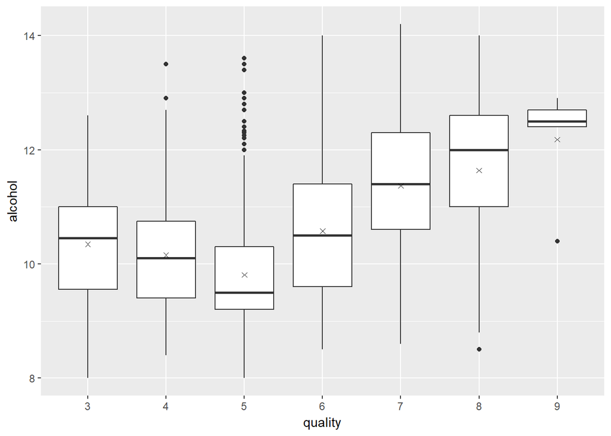

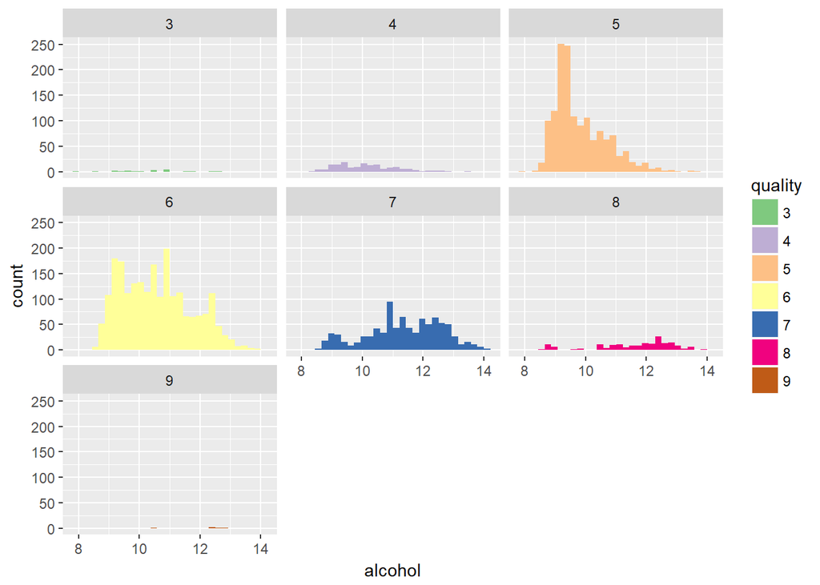

Here we have a histogram of alcohol wrapped by quality. There is a normal distribution in alcohol for the quality above 5. We can see here that wines rated above average peak around 11% alcohol.

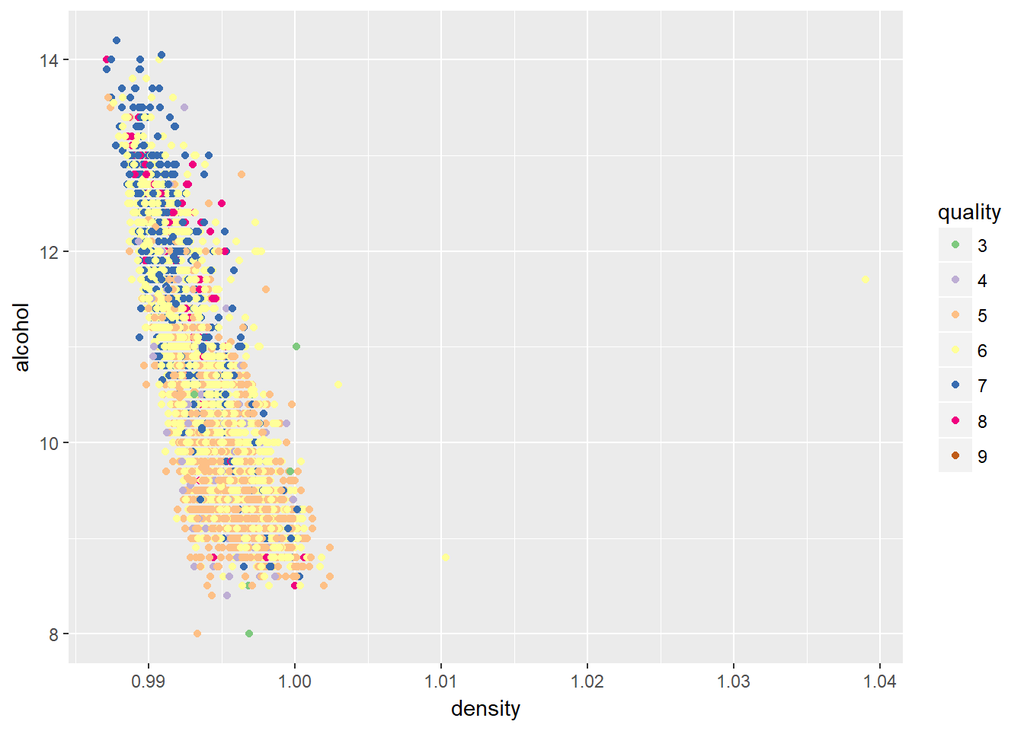

In this plot we observe a strong negative relationship between alcohol and density, especially for the wines that are rated above 5 in quality.

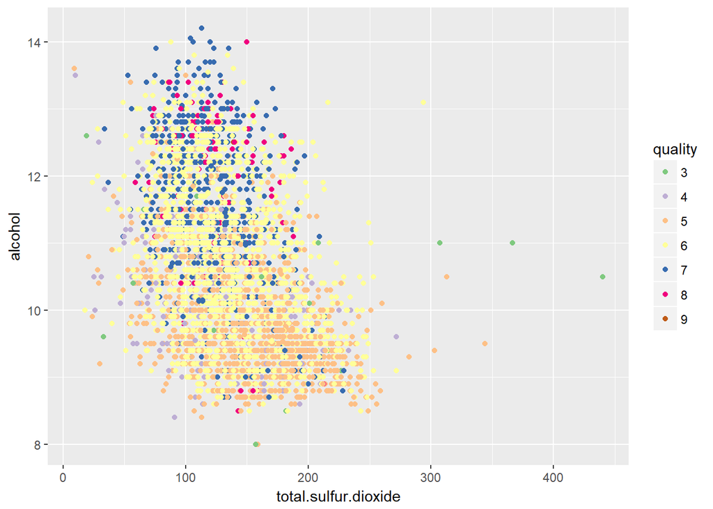

We observe here a moderate negative relationship between alcohol and total sulfur dioxide wrapped by quality, especially for the wines that are rated above 5.

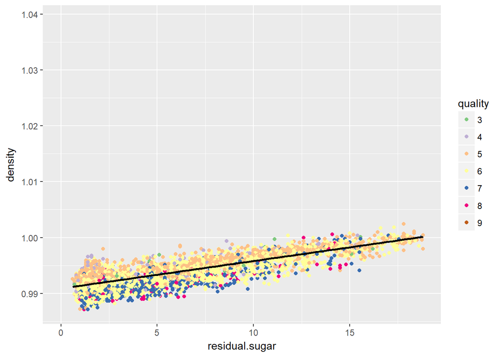

I omited here the 1% data in residual sugar. There is a strong relationship between density and residual sugar for wines rated 5 and above 5. As the amount of sugar increases the density increases.

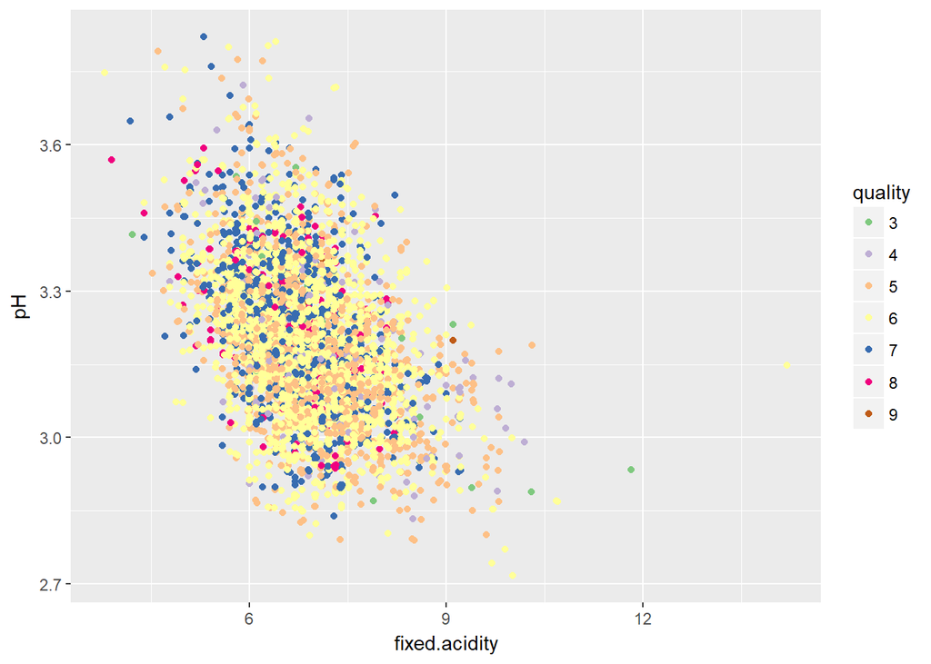

This plot shows pH for each quality in relationship with fixed acidity.

# Multivariate Analysis

### Talk about some of the relationships you observed in this part of the investigation. Were there features that strengthened each other in terms of looking at your feature(s) of interest?

I observed that wines which have a higher percent of alcohol are higher rated. Also I observed that wines which are higher rated, thus an increased percent of alcohol have a smaller density.

### Were there any interesting or surprising interactions between features?

Higher rated wines have a lower total sulfur dioxide, which means that in low concentrations sulfur dioxide is mostly undetectable.

# Final Plots and Summary

### Plot One

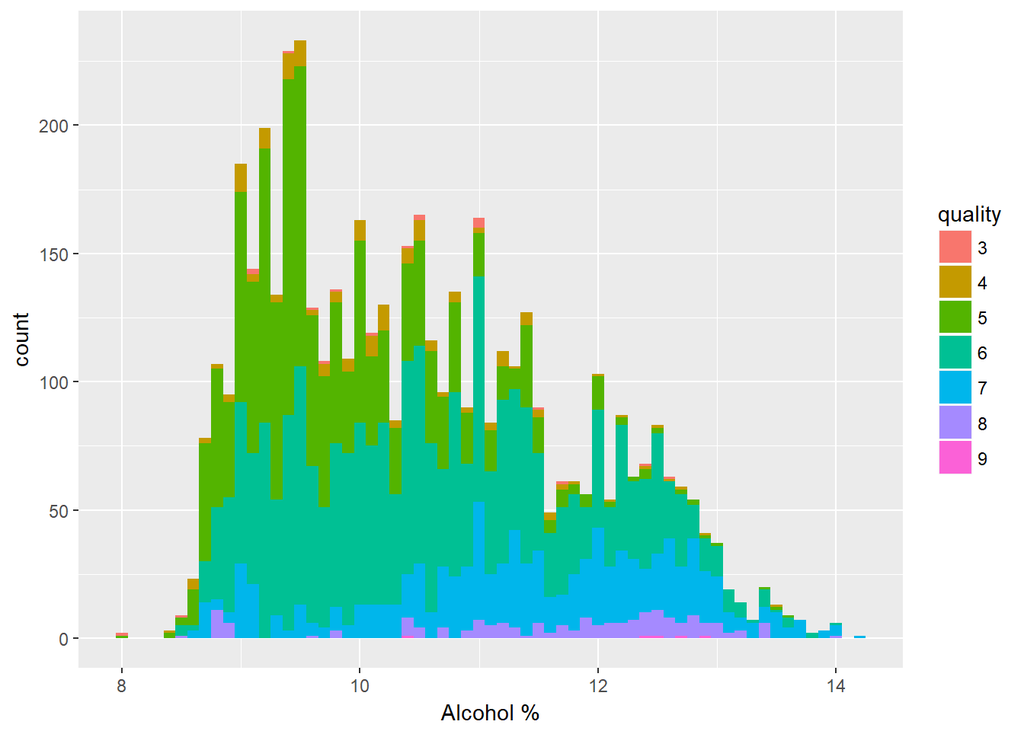

```
## $title
## [1] "Alcohol Distribution by Quality"
##
## $subtitle
## NULL
##
## attr(,"class")
## [1] "labels"
```

### Description One

Here we have the distribution of the percent alcohol content of the wine. It appears to be slightly skewed with the alcohol peaking at around 9.5. However, if we look at the higher rated wines, we see that the peak is around 11. So, wines rated above average have a higher percent of alcohol.

### Plot Two

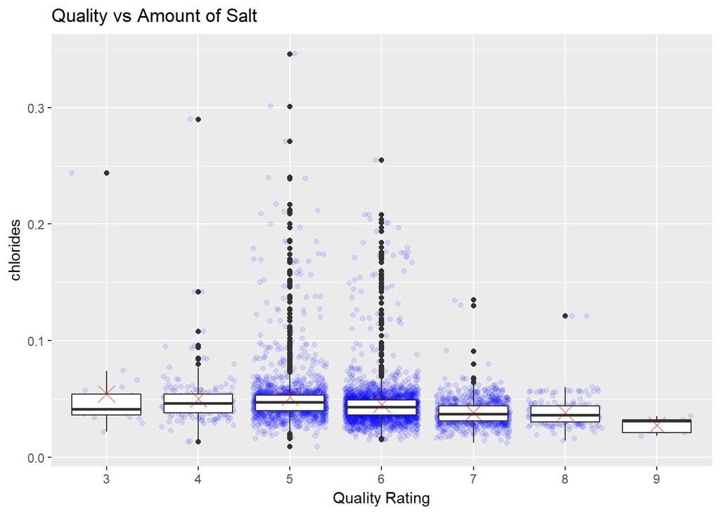

### Description Two

There is a small negative relationship between quality and amount of salt in wine. This means that higher rated wines have less salt than the lower rated wines. We can clearly see that as the mean decreases in salt the quality increases.

### Plot Three

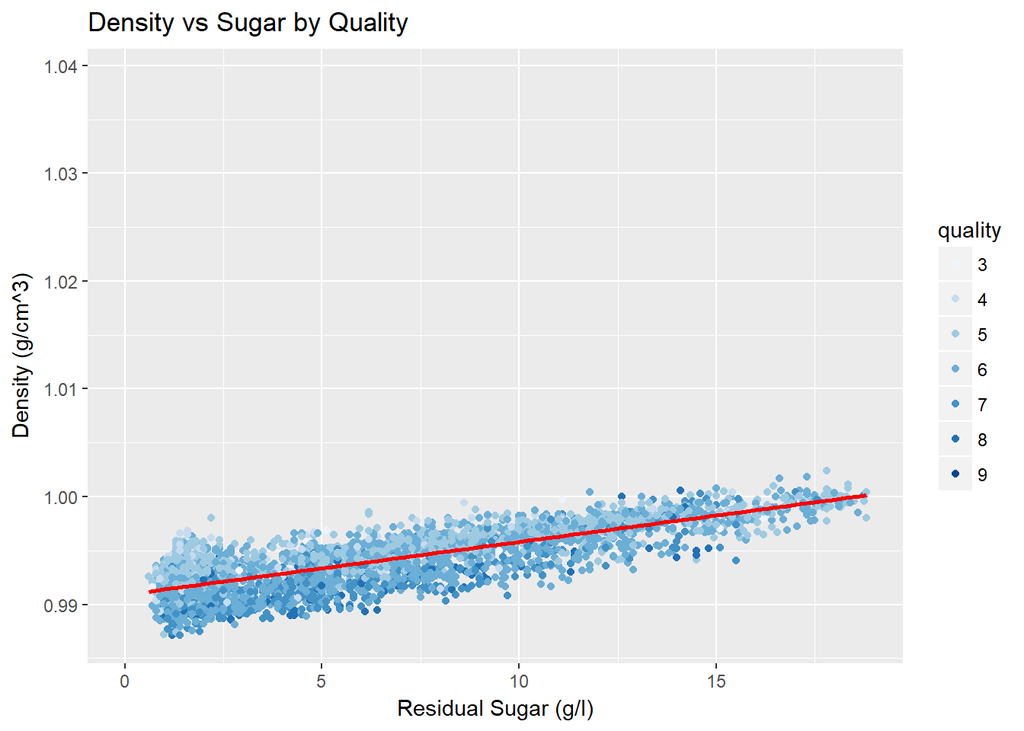

# Reflection

I was expected that the main features like pH, residual sugar, acid citric and volatile acidity would have a direct impact over the quality of the wine, but it seems they have in combination with other features.

The challenges I enocountered were the fact the variables were not clearly explained as they represent chemical properties. We need to make sure we understand them so that we are able to present them in a concise and clear manner, so that the audience would know what we are talking about.

On the other hand, I found a tidy data set which was easy to work with as I didn’t have to struggle with cleaning the data.

Overall I am content about the data set I have analyzed and of the insights I found. I didn’t expect to find features that I wouldn’t think about to contribute to the wines quality ratings.

For the future I would perform further analyses outside EDA in order to confirm the findings or find some insights that perhaps are not obvious at this stage.